# Results walk-through

Ross Cunning

2018-07-24

# Genome statistics

|  | *Pdam* | *Spis*[^1] | *Adig*[^2] | *Ofav*[^3] | *Disc*[^4] | *Afen*[^5] | *Aipt*[^6] | *Nema*[^7] | *Hydr*[^8] | *Mlei*[^9] | *Aque*[^10] |
| --- | --- | --- | --- | --- | --- | --- | --- | --- | --- | --- | --- |
| Genome size (Mb) | 348<sup>$</sup> | 434 | 420 |  | 428 | 350 | 260 | 329[^11] | 1300 |  | 190 |
| Assembly size (Mb) | 234 | 400 | 419 | 486 | 445 | 370 | 258 | 356 | 852 | 156 | 167 |
| Total contig size (Mb) | 226 | 358 | 365 | 356 | 364 | 306 | 213 | 297 | 785 | 150 | 145 |
| Contig / Assembly (%) | 96.3 | 89.5 | 87.0 | 73.3 | 81.9 | 82.6 | 82.5 | 83.4 | 92.2 | 96.5 | 86.8 |
| Contig N50 (kb) | 25.9 | 14.9 | 10.9 | 7.4 | 18.7 | 20.1 | 14.9 | 19.8 | 9.7 | 11.9 | 11.2 |
| Scaffold N50 (kb) | 326 | 457 | 191 | 1162 | 770 | 510 | 440 | 472 | 92.5 | 187 | 120 |
| # Gene models | 26,077 | 25,769* | 23,668 | 37,660 | 23,199 | 21,372 | 29,269 | 27,273 | 31,452 | 16,554 | 29,867 |
| # Complete gene models | 21,389 | 25,563* | 16,434 | 29,679 | 16,082* | 15,552* | 26,658 | 13,343 |  |  |  |
| BUSCO completeness (%) | 88.4 | 72.2 | 34.3 | 71.0 |  |  |  |  |  |  |  |
| Mean exon length (bp) | 245 | 262* | 230 | 240 | 226 | 218 | 354 | 208 |  | 314 |  |
| Mean intron len. (bp) | 667 | 917* | 952 | 1146 | 1119 | 1047 | 638 | 800 |  | 898 | 80 |
| Mean protein len. (aa) | 455 | 615* | 424 | 413 | 450* | 475* | 517 | 331 |  | 154? | 280(med) |

* Calculated in this study using GAG based on publicly available data  
^ Calculated in this study using RepeatModeler and RepeatMasker  
<sup>$</sup> Computed as the total occurrences for non-error k-mers divided by the homozygous-peak depth (Dovetail Genomics Assembly Report)

# Feature frequency profiling based on all gene models

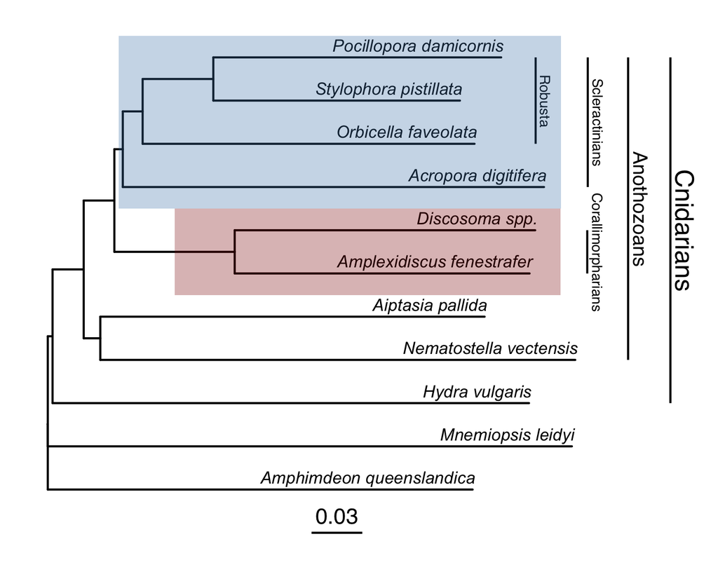

```r
tree <- ape::read.tree("ffp/tree")
tree <- root(tree, "Mnemiopsis")
tree <- drop.tip(tree, c(1,3,6))
tree$tip.label <- c("Orbicella faveolata", "Pocillopora damicornis", "Stylophora pistillata", "Amplexidiscus fenestrafer", "Discosoma spp.", "Aiptasia pallida", "Nematostella vectensis", "Hydra vulgaris", "Amphimdeon queenslandica", "Mnemiopsis leidyi", "Acropora digitifera")

p <- ggtree(tree) +
  #geom_text2(aes(subset=!isTip, label=node), hjust=-.3) +
  geom_tiplab(aes(fontface = 'italic'), size = 3, vjust = -0.5, hjust = 'right') +
  #geom_tiplab(size=3, vjust=-0.5, hjust = 'right') +
  geom_cladelabel(node=13, label = "Cnidarians", offset = 0.05,
                  angle = 270, hjust = 'center', vjust = 'bottom', fontsize = 4.5) +
  geom_cladelabel(node=14, label = "Anothozoans", offset = 0.025,
                  angle = 270, hjust = 'center', vjust = 'bottom', fontsize = 3.5) +
  geom_cladelabel(node=16, label = "Scleractinians", offset = 0.02,
                  angle = 270, hjust = 'center', vjust = 'bottom', fontsize = 2.5) +
  geom_cladelabel(node=17, label = "Robusta", offset = 0.015,
                  angle = 270, hjust = 'center', vjust = 'bottom', fontsize = 2.5) +
  geom_cladelabel(node=19, label = "Corallimorpharians", offset = 0.025,
                  angle = 270, hjust = 'center', vjust = 'bottom', fontsize = 2.5) +
  geom_hilight(node=16, fill='steelblue',alpha=0.3, extend=0.01) +
  geom_hilight(node=19, fill='darkred',alpha=0.3, extend=0.015) +
  geom_treescale()

p2 <- rotate(p, c(18))
p3 <- rotate(p2, 20)

ggsave(filename = "figures/Fig1_tree.png", plot = p3, device = "png", height = 4, width = 5, units = "in")
```

# Gene content analysis

## Counts of ortholog groups / gene families

```r
# How many gene families, including singletons, were found across all the genomes?
nrow(counts)
```

```
## [1] 98499
```

```r
# How many non-singleton gene families were found across all genomes?
nrow(counts[rowSums(counts) > 1, ])
```

```
## [1] 29115
```

```r
# How many gene families, including singletons, were found in at least one scleractinian?
scler_genefams <- counts %>%
  select("Pdam", "Adig", "Spis", "Ofav") %>%
  filter(rowSums(.) > 0)
nrow(scler_genefams)
```

```
## [1] 43580
```

```r
# How many gene families, including singletons, were found in more than one scleractinian?
sum(apply(scler_genefams, 1, FUN=function(x) sum(x>0)>1))
```

```
## [1] 14653
```

```r
# Size range of all gene families in scleractinians
range(rowSums(scler_genefams))
```

```
## [1]   1 566
```

## Number of gene families shared by scleractinian species

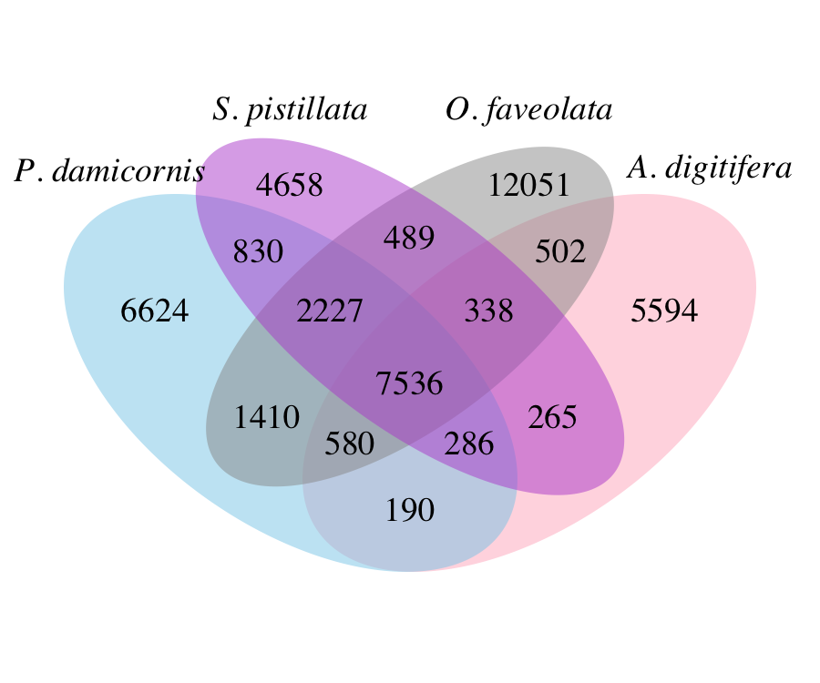

```r
png(filename="figures/Fig2_coral_venn.png", width=3, height=2.5, units="in", res=300)
# Compare four coral species
## Venn diagram
plotGeneFams(c("Pdam", "Adig", "Spis", "Ofav"),
             category=make.italic(c("P. damicornis", "A. digitifera",
                                    "S. pistillata", "O. faveolata")),
             lty="blank", fill=c("skyblue", "pink1", "mediumorchid", "gray60"),
             cat.cex=0.75, cex=0.75, margin=0.075)
dev.off()

## Dendrogram
l <- t(combn(c("Pdam", "Spis", "Adig", "Ofav"), 2))
gd <- apply(l, 1, function(p) genedist(p[1], p[2]))
df <- data.frame(cbind(l, gd))
dm <- reshape(df, direction="wide", idvar="V2", timevar="V1")
dm <- cbind(rbind(rep(NA, 4), dm), rep(NA, 4))
dm <- dm[,-1]
rownames(dm) <- c("Pdam", "Spis", "Adig", "Ofav")
colnames(dm) <- c("Pdam", "Spis", "Adig", "Ofav")

dd <- as.dendrogram(hclust(as.dist(dm)))
dd.reorder <- reorder(dd, c(1,3,2222222,1111111))

png("figures/Fig2_coral_genecontent_dendro.png", width=2, height=1, units="in", res=300)
par(mar=c(0,0,0,0))
plot(as.hclust(dd.reorder), xlab=NA, sub=NA, yaxt="n", ylab=NA, main=NA, cex=0.75)
dev.off()
```

Venn diagram shows the number of gene families shared by each of the four coral species. A pairwise similarity metric can be calculated for each pair of corals as the number of shared gene families divided by their total number of gene families (based on Snel et al. 1999). Based on this similarity metric, a dendrogram can be created showing the relationships among all four corals. Relationships based on shared gene families are consistent with evolutionary phylogeny.

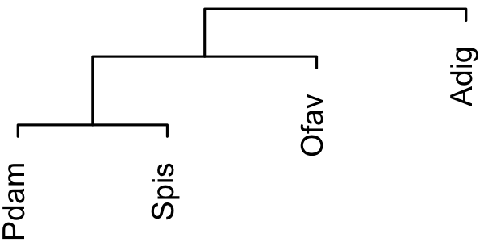

## ‘Core’ coral ortholog groups

These are gene families found in all scleractinian genomes, without regard to their present in non-scleractinian genomes.

```r
# Number of coral core gene families
coralCore <- counts[apply(counts[,1:4], 1, function(x) min(x)>0), ]
(n.coral.core <- nrow(coralCore))
```

```
## [1] 7536
```

```r
# Number of P. damicornis genes that are members of coral core gene families
sum(coralCore$Pdam)
```

```
## [1] 12147
```

```r
sum(coralCore$Pdam) / sum(counts$Pdam)
```

```
## [1] 0.4658128
```

```r
present.all.cni <- sum(apply(coralCore[,5:9], 1, function(x) min(x)>0))
pct.all.cni <- present.all.cni / n.coral.core

present.one <- sum(apply(coralCore[,-(1:4)], 1, function(x) max(x)>0))
pct.present.one <- present.one / n.coral.core
```

The coral core genome (orthologs present in all four scleractinians) includes 7536 gene families. Of these genes, 31.2% are present in all other cnidarians, and 96.31% are present in at least one non-coral genome. Functional analysis of these core genes in *P. damicornis* revealed enrichment of 44 GO terms:

##### Supplementary Data S1: GO terms enriched in coral core gene families

```r
S1 <- read_csv("orthologs/coral_core/coral_core_enrichment_data.csv") %>%
  select(1, 2, 4, 5, 9) %>%
  rename(Observed = Significant,
         p = topgoFisher)
write_csv(S1, path = "output/Supplementary_Data_S1.csv")

knitr::kable(S1, caption="Enrichment of GO terms in the coral core gene set.")
```

Enrichment of GO terms in the coral core gene set.

| GO.ID | Term | Observed | Expected | p |
| --- | --- | --- | --- | --- |
| GO:0006355 | regulation of transcription DNA-templat… | 380 | 309.81 | 0.0000000 |
| GO:0035556 | intracellular signal transduction | 242 | 195.84 | 0.0000004 |
| GO:0007018 | microtubule-based movement | 68 | 47.86 | 0.0000008 |
| GO:0006886 | intracellular protein transport | 84 | 64.86 | 0.0000012 |
| GO:0006511 | ubiquitin-dependent protein catabolic pr… | 63 | 45.34 | 0.0000073 |
| GO:0016579 | protein deubiquitination | 36 | 23.93 | 0.0000140 |
| GO:0016192 | vesicle-mediated transport | 113 | 78.08 | 0.0000270 |
| GO:0055114 | oxidation-reduction process | 402 | 353.89 | 0.0000530 |
| GO:0006281 | DNA repair | 106 | 78.08 | 0.0000920 |
| GO:0006357 | regulation of transcription from RNA pol… | 52 | 35.89 | 0.0000930 |
| GO:0055085 | transmembrane transport | 405 | 363.97 | 0.0003400 |
| GO:0035023 | regulation of Rho protein signal transdu… | 33 | 23.30 | 0.0003500 |
| GO:0006397 | mRNA processing | 51 | 40.93 | 0.0007900 |
| GO:0006351 | transcription DNA-templated | 440 | 353.89 | 0.0009100 |
| GO:0008152 | metabolic process | 2860 | 2529.52 | 0.0013300 |
| GO:0006396 | RNA processing | 149 | 116.50 | 0.0030000 |
| GO:0006887 | exocytosis | 25 | 16.37 | 0.0038300 |
| GO:0006364 | rRNA processing | 22 | 14.48 | 0.0062700 |
| GO:0006464 | cellular protein modification process | 603 | 546.58 | 0.0063900 |
| GO:0006338 | chromatin remodeling | 15 | 10.08 | 0.0097400 |
| GO:0043087 | regulation of GTPase activity | 16 | 11.33 | 0.0097500 |
| GO:0006298 | mismatch repair | 10 | 6.30 | 0.0097700 |
| GO:0045454 | cell redox homeostasis | 41 | 32.74 | 0.0105500 |
| GO:0006260 | DNA replication | 50 | 39.04 | 0.0138800 |
| GO:0030036 | actin cytoskeleton organization | 35 | 25.82 | 0.0153500 |
| GO:0006096 | glycolytic process | 9 | 5.67 | 0.0155200 |
| GO:0006904 | vesicle docking involved in exocytosis | 9 | 5.67 | 0.0155200 |
| GO:0007224 | smoothened signaling pathway | 9 | 5.67 | 0.0155200 |
| GO:0046854 | phosphatidylinositol phosphorylation | 9 | 5.67 | 0.0155200 |
| GO:0006457 | protein folding | 39 | 31.49 | 0.0197900 |
| GO:0060271 | cilium morphogenesis | 14 | 10.08 | 0.0210700 |
| GO:0006099 | tricarboxylic acid cycle | 12 | 8.19 | 0.0210800 |
| GO:0006810 | transport | 837 | 756.90 | 0.0238300 |
| GO:0005975 | carbohydrate metabolic process | 190 | 163.72 | 0.0240800 |
| GO:0006139 | nucleobase-containing compound metabolic… | 935 | 760.68 | 0.0242000 |
| GO:0007156 | homophilic cell adhesion via plasma memb… | 25 | 19.52 | 0.0277900 |
| GO:0007264 | small GTPase mediated signal transductio… | 109 | 86.27 | 0.0311200 |
| GO:0006629 | lipid metabolic process | 138 | 126.57 | 0.0349100 |
| GO:0009072 | aromatic amino acid family metabolic pro… | 11 | 6.93 | 0.0391100 |
| GO:0016226 | iron-sulfur cluster assembly | 8 | 5.04 | 0.0391700 |
| GO:0006207 | ‘de novo’ pyrimidine nucleobase biosynth… | 7 | 4.41 | 0.0392000 |
| GO:0007020 | microtubule nucleation | 7 | 4.41 | 0.0392000 |
| GO:0046856 | phosphatidylinositol dephosphorylation | 7 | 4.41 | 0.0392000 |
| GO:0070588 | calcium ion transmembrane transport | 29 | 23.30 | 0.0437100 |

## Coral-specific genes

```r
# Number of coral specific gene families (present in all coral genomes and not in any other genomes)
coral.specific <- apply(counts, 1, function(x) min(x[1:4]>0) & max(x[-(1:4)])==0)
coral.specific.orthos <- counts[coral.specific, ]
n.coral.specific.orthos <- nrow(coral.specific.orthos)
n.coral.specific.orthos
```

```
## [1] 278
```

```r
n.coral.specific.singletons <-with(coral.specific.orthos, sum(Pdam==1 & Spis==1 & Adig==1 & Ofav==1))
n.coral.specific.genes <- sum(coral.specific.orthos[,1]) #(in Pdam)

# How many of the coral-specific genes in Pdam had GO annotations?
cs_in_pdam <- read.table("orthologs/coral_specific/coral_specific_pdam_gene_names.txt")  # contains the 349 coral-specific genes in Pdam
pdam_GO <- read.table("annotation/pdam_genes_GO.txt", sep="\t")  # contains GO annotations for all genes in Pdam
cs_in_pdam_with_GO_annot <- intersect(cs_in_pdam$V1, pdam_GO$V1)
length(cs_in_pdam_with_GO_annot) / length(cs_in_pdam$V1)
```

```
## [1] 0.5272206
```

This is a set of genes for which orthologs were present *in all coral genomes* but *NOT* in any of the other genomes. There were 278 coral-specific gene families, including 143 that were single-copy in each coral. In Pdam, these coral-specific gene families comprised a total of 349 genes. As above, the GO terms for these Pdam genes were tested for enrichment relative to the whole Pdam genome using topGO. Nine GO terms were significantly enriched.

```r
csgo <- read_csv("orthologs/coral_specific/coral_specific_enrichment_data.csv") %>%
  select(1,2,4,5,9) %>%
  rename(Observed = Significant,
         p = topgoFisher)
knitr::kable(csgo, caption="Enrichment of GO terms in the coral-specific gene set.")
```

Enrichment of GO terms in the coral-specific gene set.

| GO.ID | Term | Observed | Expected | p |
| --- | --- | --- | --- | --- |
| GO:0035434 | copper ion transmembrane transport | 2 | 0.10 | 0.0040 |
| GO:0007165 | signal transduction | 32 | 23.78 | 0.0042 |
| GO:0046654 | tetrahydrofolate biosynthetic process | 1 | 0.01 | 0.0123 |
| GO:0051092 | positive regulation of NF-kappaB transcr… | 1 | 0.02 | 0.0245 |
| GO:0070836 | caveola assembly | 1 | 0.04 | 0.0365 |
| GO:0051607 | defense response to virus | 2 | 0.32 | 0.0403 |
| GO:0006355 | regulation of transcription DNA-templat… | 12 | 6.06 | 0.0456 |
| GO:0000183 | chromatin silencing at rDNA | 1 | 0.05 | 0.0484 |
| GO:0045132 | meiotic chromosome segregation | 1 | 0.05 | 0.0484 |

### Count number of Pdam genes with TNFR cysteine-rich domains annotated by InterProScan

```bash
grep "TNFR" annotation/interproscan/pdam_ips.renamed.tsv > annotation/interproscan/TNFR
cat annotation/interproscan/TNFR | cut -f1 | uniq | wc -l
```

```
##       39
```

## Gene families diversified in corals

```r
coral <- 1:4
morph <- 5:6
anem <- 7:8
noncoranth <- 5:8
minanth <- apply(counts[,c(coral,morph,anem)],1,min)
sumcor <- apply(counts[,coral],1,sum)

anth <- counts[,1:8]
pgens <- anth[which(minanth>0 & sumcor>20),] # genes to test
divp <- c()
for (g in rownames(pgens)) {
  df <- data.frame(members=rep(NA,8), nonmembers=NA, group=NA)
  rownames(df) <- colnames(anth)
  df["Pdam",1:2] <- c(sum(anth[g,"Pdam"]), sum(anth[-which(rownames(anth) %in% g),"Pdam"]))
  df["Spis",1:2] <- c(sum(anth[g,"Spis"]), sum(anth[-which(rownames(anth) %in% g),"Spis"]))
  df["Adig",1:2] <- c(sum(anth[g,"Adig"]), sum(anth[-which(rownames(anth) %in% g),"Adig"]))
  df["Ofav",1:2] <- c(sum(anth[g,"Ofav"]), sum(anth[-which(rownames(anth) %in% g),"Ofav"]))
  df["Ampl",1:2] <- c(sum(anth[g,"Ampl"]), sum(anth[-which(rownames(anth) %in% g),"Ampl"]))
  df["Disc",1:2] <- c(sum(anth[g,"Disc"]), sum(anth[-which(rownames(anth) %in% g),"Disc"]))
  df["Aipt",1:2] <- c(sum(anth[g,"Aipt"]), sum(anth[-which(rownames(anth) %in% g),"Aipt"]))
  df["Nema",1:2] <- c(sum(anth[g,"Nema"]), sum(anth[-which(rownames(anth) %in% g),"Nema"]))
  df[,"group"] <- c(rep("coral",4), rep("noncoral",4))
  mod <- glm(cbind(members, nonmembers) ~ group, data=df, family="binomial")
  lsm <- lsmeans(mod, specs="group")
  lsmtest <- test(contrast(lsm, "trt.vs.ctrl", ref=2), side=">")
  divp[g] <- lsmtest$p.value
}
divadj <- p.adjust(divp,method="fdr")
divs <- pgens[divadj<0.01,]
#pdivGens <- dat[dat$Group%in%rownames(divs),]

(n.coral.div.orthos <- nrow(divs))  # number of gene families larger in scleractinians than other anthozoans
```

```
## [1] 21
```

```r
n.coral.div.genes <- sum(divs[,1]) # number of members of these gene families in Pdam

# How many of the coral-diversified genes in Pdam had annotations?
div_in_pdam <- read.table("orthologs/coral_diversified/coral_diversified_pdam_gene_names.txt")  # contains the 349 coral-specific genes in Pdam

pdam_GO <- read.table("annotation/pdam_genes_GO.txt", sep="\t")  # contains GO annotations for all genes in Pdam

div_in_pdam_with_GO_annot <- intersect(div_in_pdam$V1, pdam_GO$V1)
length(div_in_pdam_with_GO_annot) / length(div_in_pdam$V1)
```

```
## [1] 0.6755162
```

```r
cdgo <- read_csv("orthologs/coral_diversified/coral_diversified_enrichment_data.csv") %>%
  select(1,2,4,5,9) %>%
  rename(Observed = Significant,
         p = topgoFisher)
knitr::kable(cdgo, caption="Enrichment of GO terms in the coral-diversified gene set.")
```

Enrichment of GO terms in the coral-diversified gene set.

| GO.ID | Term | Observed | Expected | p |
| --- | --- | --- | --- | --- |
| GO:0006857 | oligopeptide transport | 3 | 0.05 | 0.000015 |
| GO:0007264 | small GTPase mediated signal transductio… | 6 | 1.05 | 0.000600 |
| GO:0001822 | kidney development | 2 | 0.05 | 0.000850 |
| GO:0006468 | protein phosphorylation | 11 | 3.82 | 0.001960 |
| GO:0007219 | Notch signaling pathway | 2 | 0.11 | 0.004980 |
| GO:0033151 | V(D)J recombination | 1 | 0.01 | 0.007680 |
| GO:0045737 | positive regulation of cyclin-dependent … | 1 | 0.01 | 0.007680 |
| GO:0008152 | metabolic process | 31 | 30.87 | 0.012710 |
| GO:0016255 | attachment of GPI anchor to protein | 1 | 0.04 | 0.037840 |

```r
# Get top SwissProt hits for coral-diversified proteins (using longest as representative set)
sphits <- read.table("orthologs/coral_diversified/cd_longest_sp_tophits.txt", sep="\t")
sphits$V1 <- str_replace_all(sphits$V1, "-RA", "")
fams <- read.table("orthologs/coral_diversified/longest_genes-fams.txt", row.names=NULL)
sphits <- merge(fams, sphits, by="V1")
sphits$labels <- stringr::str_extract(as.character(sphits$V9), " [^O]*")

# heatmap of gene family size of coral-diversified genes
rot <- function(x) "[<-"(x, , rev(x))
flip <- function(x) apply(x, 2, rot)
png("figures/Fig3_coral_divgenes_heatmap.png", height=4, width=7, units="in", res=300)


par(mar=c(1,1,3.5,20), mgp=c(1.5,0.25,0), tcl=-0.25)
divs2 <- as.matrix(divs)
divs2 <- t(log10(divs2[hclust(dist(divs2))$order,]))
divs2 <- divs2[c(8,7,5,6,3,4,2,1), ]
hits <- sphits[match(colnames(divs2), as.character(sphits$V2.x)), "labels"]
pal <- brewer.pal(n=9, "GnBu")
GnBu <- colorRampPalette(brewer.pal(n=9, "GnBu"))
image(flip(divs2), col=GnBu(50), axes=F)
box()
axis(side=3, at=quantile(par("usr")[1:2], c(1, 3, 5, 7, 9, 11, 13, 15)*0.0625),
     labels=rev(c("Nv", "Ap", "Af", "Ds", "Ad", "Of", "Sp", "Pd")), cex.axis=0.75)
abline(v=0.5)
text(par("usr")[2]+0.01, quantile(par("usr")[3:4], seq(0.025,0.975,len=21)), hits, xpd=NA, adj=0, cex=0.75)
mtext(side=3, "Anthozoa", line=2.5, adj=0)
segments(par("usr")[1], 1.19, par("usr")[2], 1.19, xpd=NA, lwd=1.5)
mtext(side=3, "Scleractinia", line=1.3, adj=0)
segments(par("usr")[1], 1.11, 0.5, 1.11, xpd=NA, lwd=1.5)
text(par("usr")[2]-0.03, par("usr")[4]+0.04, "Top hit in UniProt-SwissProt database (E<1e-10)", xpd=NA, pos=4)
segments(par("usr")[2], 1.03, 2.6, 1.03, xpd=NA, lwd=1.5)
fields::image.plot(flip(divs2), col=GnBu(50), axes=F, legend.only=TRUE, horizontal=FALSE,
                   smallplot=c(0.89,0.92,0.05,0.5))
text(2.45, 0.65, labels = "log10 # Genes", xpd=T, cex=1)



dev.off()
```

```r
# Table with gene family size and SwissProt annotations
colnames(sphits)[1] <- "gene"
colnames(fams) <- c("gene", "ortho")
divs$ortho <- rownames(divs)
divs$pval <- divadj[rownames(divs)]
out <- merge(divs, fams)
out2 <- merge(out, sphits, by="gene", all = TRUE)[,c(2:11,1,13,18)]
colnames(out2) <- c("ortholog_group", "Pdam", "Spis", "Adig", "Ofav", "Ampl", "Disc", "Aipt",
                    "Nema", "pval", "rep_gene", "SwissProt_tophit", "E-value")
write.table(out2, file="output/Supplementary_Table_S1.txt", quote=F, row.names=F)
```

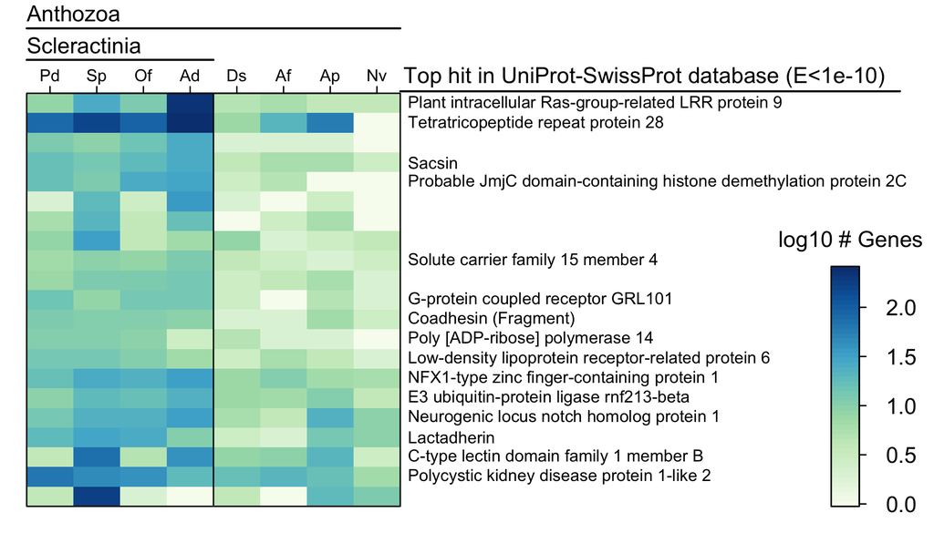

## Coral species-specific gene family expansions

### Gene family size analysis

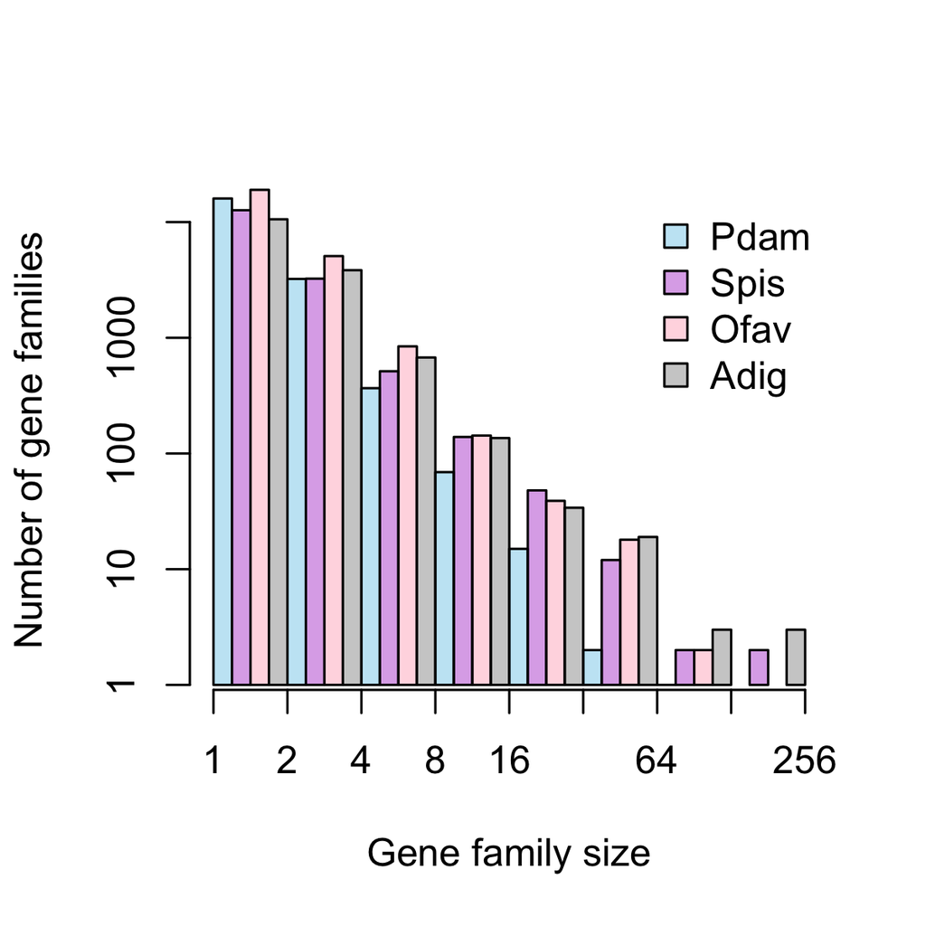

```r
par(mar=c(3,3.75,1,1), mgp=c(1.75,0.25,0), tcl=-0.2)

cols <- c("skyblue", "mediumorchid", "pink1",  "gray60")
pdam.counts <- hist(counts$Pdam[counts$Pdam>0], breaks=2^(seq(0,8,1)), right=FALSE, plot=F)
spis.counts <- hist(counts$Spis[counts$Spis>0], breaks=2^(seq(0,8,1)), right=FALSE, plot=F)
ofav.counts <- hist(counts$Ofav[counts$Ofav>0], breaks=2^(seq(0,8,1)), right=FALSE, plot=F)
adig.counts <- hist(counts$Adig[counts$Adig>0], breaks=2^(seq(0,8,1)), right=FALSE, plot=F)

logdat <- log10(rbind(pdam.counts$counts, spis.counts$counts,
                    ofav.counts$counts, adig.counts$counts))
logdat[is.infinite(logdat)] <- NA

png(filename="figures/Fig4_gene_family_size.png", width=4, height=4, units="in", res=300)
bars <- barplot(logdat, beside=T, space=c(0,0), axes=F, col=alpha(cols,0.5),
                xlab="Gene family size", ylab="Number of gene families", xpd=NA)
axis(side=1, at=c(0,4,8,12,16,20,24,28,32),
     labels=c(1,2,4,8,16,32,64,128,256))
axis(side=2, at=c(0,1,2,3,4), labels=c(1,10,100,1000,10000))
legend("topright", pch=22, pt.bg=alpha(cols, 0.5), pt.cex=1.5, bty="n",
       legend=c("Pdam", "Spis", "Ofav", "Adig"))
dev.off()
```

### Gene families diversified in each coral species

```r
# which are the most diversified gene families in each coral species?
# TEST DIFFS FOR ALL SHARED GENES
corals <- counts[, 1:4]
shared <- corals[apply(corals, 1, min)>0, ]
genestotest <- rownames(shared[apply(shared, 1, function(x) max(x)>=10),])
divp <- c()
for (g in genestotest) {
  adig1 <- sum(corals[g,3])
  adig0 <- sum(corals[-which(rownames(corals) %in% g),3])
  spis1 <- sum(corals[g,2])
  spis0 <- sum(corals[-which(rownames(corals) %in% g),2])
  pdam1 <- sum(corals[g,1])
  pdam0 <- sum(corals[-which(rownames(corals) %in% g),1])
  ofav1 <- sum(corals[g,4])
  ofav0 <- sum(corals[-which(rownames(corals) %in% g),4])
  tab <- matrix(c(adig1, spis1, pdam1, ofav1, adig0, spis0, pdam0, ofav0), nrow=4,
                  dimnames=list("Species"=c("Adig", "Spis", "Pdam", "Ofav"),
                                "GeneFam"=c("Member", "NonMember")))
  tab <- as.table(tab)
  set.seed(5234)
  divp[g] <- fisher.test(tab, simulate.p.value=TRUE)$p.value
}
padj <- p.adjust(divp, method = "fdr")
divs <- shared[names(padj[padj < 0.01]), ]


######## identify significant differences
res <- data.frame(matrix(NA, ncol=ncol(divs), nrow=nrow(divs),
                         dimnames=list("Groups"=rownames(divs), "Species"=colnames(divs))))

for (g in rownames(divs)) {
  adig1 <- sum(corals[g,3])
  adig0 <- sum(corals[-which(rownames(corals) %in% g),3])
  spis1 <- sum(corals[g,2])
  spis0 <- sum(corals[-which(rownames(corals) %in% g),2])
  pdam1 <- sum(corals[g,1])
  pdam0 <- sum(corals[-which(rownames(corals) %in% g),1])
  ofav1 <- sum(corals[g,4])
  ofav0 <- sum(corals[-which(rownames(corals) %in% g),4])
  tab <- matrix(c(adig1, spis1, pdam1, ofav1, adig0, spis0, pdam0, ofav0), nrow=4,
                dimnames=list("Species"=c("Adig", "Spis", "Pdam", "Ofav"),
                              "GeneFam"=c("Member", "NonMember")))
  tab <- as.table(tab)
  ptab <- RVAideMemoire::fisher.multcomp(tab, p.method="fdr")
  fullptab <- rcompanion::fullPTable(ptab$p.value)
  ord <- with(data.frame(prop.table(tab, 1))[1:4,], order(Freq, decreasing=T))
  fullptab.ord <- fullptab[ord, ord]
  lett <- multcompView::multcompLetters(fullptab.ord)$Letters
  lett <- lett[order(match(names(lett), colnames(divs)))]
  res[g, ] <- lett
  data.frame(prop.table(tab, 1))[1:4,]
}

obvidivs <- divs[apply(res, 1, function(x) (sum(x=="a")==1) & sum(x=="b")==3), ]
obvires <- res[apply(res, 1, function(x) (sum(x=="a")==1) & sum(x=="b")==3), ]
obvires[obvires=="a"] <- 1
obvires[obvires=="b"] <- 0
obvires2 <- sapply(obvires, as.numeric)
rownames(obvires2) <- rownames(obvires)
colSums(obvires2)
```

```
## Pdam Spis Adig Ofav
##    0   16   11    1
```

```r
adigdiv <- obvidivs[obvires$Adig==1, ]

spisdiv <- obvidivs[obvires$Spis==1, ]

ofavdiv <- obvidivs[obvires$Ofav==1, ]

pdamdiv <- obvidivs[obvires$Pdam==1, ]
```

```r
# Table with gene family size and SwissProt annotations
sd_sp_tophits <- read.table("orthologs/species_diversified/species_specific_expansions_tophits.txt",
                            sep="\t")
colnames(sd_sp_tophits)[1] <- "gene"
fams <- read.table("orthologs/species_diversified/sd_longest_genes-fams.txt")
colnames(fams) <- c("gene", "ortho")
obvidivs$ortho <- rownames(obvidivs)
obvidivs$pval <- padj[rownames(obvidivs)]
out <- merge(obvidivs, fams, all = TRUE)
out2 <- merge(out, sd_sp_tophits, by="gene", all = TRUE)[,c(2,3,4,5,6,7,1,15,13)]
colnames(out2) <- c("ortholog_group", "Pdam", "Spis", "Adig", "Ofav", "pval",
                    "rep_gene", "SwissProt_tophit", "E-value")
write.table(out2, file="output/Supplementary_Table_S2.txt", quote=F, row.names=F)

knitr::kable(out2, caption="Lineage-specific gene family expansions in corals.")
```

Lineage-specific gene family expansions in corals.

| ortholog_group | Pdam | Spis | Adig | Ofav | pval | rep_gene | SwissProt_tophit | E-value |
| --- | --- | --- | --- | --- | --- | --- | --- | --- |
| ORTHOMCL298 | 2 | 8 | 29 | 4 | 0.0016455 | aug_v2a.00365.t1 | sp\|Q7RTR2\|NLRC3_HUMAN NLR family CARD domain-containing protein 3 OS=Homo sapiens OX=9606 GN=NLRC3 PE=1 SV=2 | 0 |
| ORTHOMCL3871 | 1 | 1 | 10 | 1 | 0.0028709 | aug_v2a.02067.t1 | NA | NA |
| ORTHOMCL472 | 4 | 3 | 20 | 7 | 0.0016455 | aug_v2a.03173.t1 | sp\|B8V7S0\|CPP1_ACRMI CUB and peptidase domain-containing protein 1 (Fragment) OS=Acropora millepora OX=45264 PE=1 SV=1 | 0 |
| ORTHOMCL80 | 11 | 21 | 40 | 18 | 0.0016455 | aug_v2a.04004.t2 | sp\|Q96AY4\|TTC28_HUMAN Tetratricopeptide repeat protein 28 OS=Homo sapiens OX=9606 GN=TTC28 PE=1 SV=4 | 0 |
| ORTHOMCL15 | 2 | 4 | 255 | 5 | 0.0016455 | aug_v2a.04548.t1 | sp\|P04323\|POL3_DROME Retrovirus-related Pol polyprotein from transposon 17.6 OS=Drosophila melanogaster OX=7227 GN=pol PE=3 SV=1 | 0 |
| ORTHOMCL502 | 2 | 4 | 24 | 3 | 0.0016455 | aug_v2a.06918.t1 | NA | NA |
| ORTHOMCL77 | 3 | 6 | 28 | 2 | 0.0016455 | aug_v2a.10500.t1 | sp\|Q7LHG5\|YI31B_YEAST Transposon Ty3-I Gag-Pol polyprotein OS=Saccharomyces cerevisiae (strain ATCC 204508 / S288c) OX=559292 GN=TY3B-I PE=3 SV=2 | 0 |
| ORTHOMCL94 | 8 | 11 | 40 | 26 | 0.0016455 | aug_v2a.13437.t1 | NA | NA |
| ORTHOMCL733 | 2 | 2 | 14 | 2 | 0.0016455 | aug_v2a.15481.t1 | sp\|P54763\|EPHB2_MOUSE Ephrin type-B receptor 2 OS=Mus musculus OX=10090 GN=Ephb2 PE=1 SV=3 | 0 |
| ORTHOMCL9 | 22 | 22 | 45 | 29 | 0.0040480 | aug_v2a.18355.t1 | sp\|E9Q8T7\|DYH1_MOUSE Dynein heavy chain 1, axonemal OS=Mus musculus OX=10090 GN=Dnah1 PE=1 SV=1 | 0 |
| ORTHOMCL2424 | 2 | 1 | 12 | 2 | 0.0028709 | aug_v2a.20445.t2 | sp\|Q96DM1\|PGBD4_HUMAN PiggyBac transposable element-derived protein 4 OS=Homo sapiens OX=9606 GN=PGBD4 PE=2 SV=3 | 0 |
| ORTHOMCL2848 | 1 | 1 | 1 | 13 | 0.0040480 | ofav_00010414-RA\|ofav_00010414-RA\|ofav_00010414-RA\|ofav_00010414-RA\|ofav_00010414-RA | NA | NA |
| ORTHOMCL1901 | 1 | 12 | 3 | 1 | 0.0016455 | Spis10603 | sp\|Q9P215\|POGK_HUMAN Pogo transposable element with KRAB domain OS=Homo sapiens OX=9606 GN=POGK PE=1 SV=2 | 0 |
| ORTHOMCL23 | 4 | 163 | 1 | 2 | 0.0016455 | Spis11227 | sp\|P21328\|RTJK_DROME RNA-directed DNA polymerase from mobile element jockey OS=Drosophila melanogaster OX=7227 GN=pol PE=1 SV=1 | 0 |
| ORTHOMCL1742 | 1 | 11 | 1 | 1 | 0.0016455 | Spis12138 | sp\|O88813\|ACSL5_RAT Long-chain-fatty-acid–CoA ligase 5 OS=Rattus norvegicus OX=10116 GN=Acsl5 PE=1 SV=1 | 0 |
| ORTHOMCL706 | 2 | 12 | 1 | 2 | 0.0028709 | Spis14598 | sp\|Q9H490\|PIGU_HUMAN Phosphatidylinositol glycan anchor biosynthesis class U protein OS=Homo sapiens OX=9606 GN=PIGU PE=1 SV=3 | 0 |
| ORTHOMCL606 | 3 | 15 | 1 | 5 | 0.0028709 | Spis15792 | sp\|Q27084\|TAL2_TACTR Tachylectin-2 OS=Tachypleus tridentatus OX=6853 PE=1 SV=1 | 0 |
| ORTHOMCL114 | 2 | 60 | 3 | 2 | 0.0016455 | Spis17249 | NA | NA |
| ORTHOMCL68 | 13 | 32 | 12 | 22 | 0.0090820 | Spis18451 | sp\|Q9UGM3\|DMBT1_HUMAN Deleted in malignant brain tumors 1 protein OS=Homo sapiens OX=9606 GN=DMBT1 PE=1 SV=2 | 0 |
| ORTHOMCL286 | 3 | 27 | 2 | 2 | 0.0016455 | Spis19594 | sp\|Q96DM1\|PGBD4_HUMAN PiggyBac transposable element-derived protein 4 OS=Homo sapiens OX=9606 GN=PGBD4 PE=2 SV=3 | 0 |
| ORTHOMCL181 | 4 | 32 | 3 | 3 | 0.0016455 | Spis2083 | NA | NA |
| ORTHOMCL851 | 2 | 17 | 3 | 1 | 0.0016455 | Spis22308 | sp\|Q09575\|YRD6_CAEEL Uncharacterized protein K02A2.6 OS=Caenorhabditis elegans OX=6239 GN=K02A2.6 PE=4 SV=1 | 0 |
| ORTHOMCL372 | 3 | 16 | 1 | 5 | 0.0016455 | Spis23235 | sp\|O75460\|ERN1_HUMAN Serine/threonine-protein kinase/endoribonuclease IRE1 OS=Homo sapiens OX=9606 GN=ERN1 PE=1 SV=2 | 0 |
| ORTHOMCL121 | 9 | 31 | 7 | 4 | 0.0016455 | Spis2940 | NA | NA |
| ORTHOMCL120 | 2 | 62 | 2 | 3 | 0.0016455 | Spis3249 | sp\|A0MSJ1\|CRA1B_DANRE Collagen alpha-1(XXVII) chain B OS=Danio rerio OX=7955 GN=col27a1b PE=2 SV=1 | 0 |
| ORTHOMCL517 | 2 | 18 | 1 | 2 | 0.0016455 | Spis332 | sp\|P21328\|RTJK_DROME RNA-directed DNA polymerase from mobile element jockey OS=Drosophila melanogaster OX=7227 GN=pol PE=1 SV=1 | 0 |
| ORTHOMCL100 | 7 | 25 | 7 | 8 | 0.0016455 | Spis7114 | sp\|P29119\|FURI1_XENLA Furin-1 OS=Xenopus laevis OX=8355 GN=furin PE=2 SV=1 | 0 |
| ORTHOMCL707 | 1 | 18 | 1 | 1 | 0.0016455 | Spis9925 | sp\|G2HE57\|DRC7_PANTR Dynein regulatory complex subunit 7 OS=Pan troglodytes OX=9598 GN=DRC7 PE=2 SV=1 | 0 |

## Pdam-specific genes

```r
pdam.specific <- apply(counts[,-1], 1, function(x) max(x)==0)
pdam.specific.orthos <- counts[pdam.specific, ]
(n.pdam.specific.orthos <- nrow(pdam.specific.orthos))
```

```
## [1] 6250
```

```r
(n.pdam.specific.singletons <- sum(pdam.specific.orthos$Pdam==1))
```

```
## [1] 5905
```

```r
(n.pdam.specific.genes <- sum(pdam.specific.orthos[,1]))
```

```
## [1] 6966
```

```r
pds_gene_names <- read.table("orthologs/pdam_specific/pdam_specific_gene_names.txt")
pdam_specific_genes_with_GO_annotations <- intersect(pds_gene_names$V1, pdam_GO$V1)
length(pdam_specific_genes_with_GO_annotations) / length(pds_gene_names$V1)
```

```
## [1] 0.2150445
```

This is a functional profile of the genes in Pdam for which *no orthologs were found in any other genome* (with an e-value cutoff of 1e-5), including the other corals and the other inverts. There were 6250 pdam-specific ortholog groups, including 5905 singletons, containing a total of 6966 genes. Eleven GO terms were significantly enriched: G-protein coupled receptor signaling pathway, bioluminescence, activation of NFkappaB-inducing kinase activity, positive regulation of JNK cascade, and signal transduction.

```r
pdam_specific <- read.csv("orthologs/pdam_specific/pdam_specific_enrichment_data.csv", stringsAsFactors = F)
pdam_specific <- pdam_specific[, c(1,2,4,5,9)]
colnames(pdam_specific) <- c("GO Accession", "GO Term Name", "Observed", "Expected", "p")
pdam_specific[1,2] <- "G-protein coupled receptor signaling pathway"
pdam_specific[3,2] <- "activation of NF-kappaB-inducing kinase activity"
write.csv(pdam_specific, "output/Table3_pdam_specific_GO_enrichment.csv", row.names=F, quote=F)

knitr::kable(pdam_specific, output="markdown", caption="Enrichment of GO terms in the P. damicornis-specific gene set.")
```

Enrichment of GO terms in the P. damicornis-specific gene set.

| GO Accession | GO Term Name | Observed | Expected | p |
| --- | --- | --- | --- | --- |
| GO:0007186 | G-protein coupled receptor signaling pathway | 407 | 149.36 | <1e-30 |
| GO:0008218 | bioluminescence | 15 | 3.24 | 6e-08 |
| GO:0007250 | activation of NF-kappaB-inducing kinase activity | 10 | 3.48 | 0.0014 |
| GO:0046330 | positive regulation of JNK cascade | 10 | 3.48 | 0.0014 |
| GO:0007165 | signal transduction | 478 | 231.92 | 0.0018 |
| GO:0035278 | miRNA mediated inhibition of translation | 5 | 1.68 | 0.0196 |
| GO:0007411 | axon guidance | 3 | 0.72 | 0.0261 |
| GO:0035385 | Roundabout signaling pathway | 3 | 0.72 | 0.0261 |
| GO:0006814 | sodium ion transport | 11 | 6.25 | 0.0419 |
| GO:0050482 | arachidonic acid secretion | 5 | 2.04 | 0.0446 |
| GO:0015074 | DNA integration | 11 | 6.37 | 0.0474 |

[^1]: Voolstra et al., bioRxiv
[^2]: @Shinzato2011
[^3]: 1. Assembly was downloaded (https://www.ncbi.nlm.nih.gov/genome/?term=txid48498) and re-annotated using the pipeline from the present study (github.com/jrcunning/ofav-genome)
[^4]: @Wang2017a
[^5]: @Wang2017a
[^6]: @Baumgarten2015
[^7]: @Putnam2007
[^8]: @Chapman2010
[^9]: @Ryan2013
[^10]: @Srivastava2010
[^11]: @Baumgarten2015